# NI TB Genomic Surveillance

Outbreak Investigation Report — generated 2026-05-14 10:51:20 UTC · Full HTML

INCOMPLETE — Appendices missing; not eligible for circulation

## Executive summary

Notified cases

25

Population denominator

Sequenced

20

QC-pass genomes

12

of 20 sequenced (60.0%)

QC unresolved

12 passed

Open clusters

3

2 priority >10

Model links ≥0.70

23

Posterior ≥0.70 — validate with SNP+epi

SNP links ≤12

0

Direct transmission candidates

Model reliability

Exploratory

MCMC convergence

**No SNP-supported direct transmission links identified.** Zero pairwise SNP links at ≤12 SNPs exist in this dataset. All 23 model link(s) ≥0.70 posterior probability are *exploratory only* and must not trigger field investigation without SNP ≤12 and epidemiological corroboration.

**Governance gate passed.** Reproducibility metadata is complete. Publish only after information-governance review.

## Top actions due now

Items marked **model-only** or **exploratory** require genomic validation and epidemiological corroboration before operational action.

[output not shown]

## MDT governance summary

| Priority area | Current signal | Required MDT action |
| --- | --- | --- |
| Circulation readiness | Governance ready | Complete mandatory reproducibility metadata before external circulation |
| Model reliability | Exploratory | Treat directionality as exploratory; diagnostics may be unavailable |
| Open clusters | 3 total / 2 priority >10 | MDT review and epi data completion for all open clusters |
| Discordant model links | 24 identified | Pairwise SNP + epi adjudication required |
| MDT sign-off status | Pending — MDT review required | Chair to record: accepted / rejected / deferred for each open cluster |
| Decision log | Not yet completed | Document MDT decisions in case management system; date-stamp and countersign |
| QC failures | 8 fail / 1 contamination | Resolve before cluster assignment and model inference |

## About this report

This report is produced by the Northern Ireland TB Genomic Surveillance platform using whole-genome sequencing (WGS) data and epidemiological case records. It supports TB programme staff and public health investigators by providing genomic evidence for transmission clusters, drug-resistance profiles, and programme performance metrics.

**Decision-support tool only.** All findings must be reviewed and acted on by a qualified clinician or public health professional. No automated decisions are made.

## Population and denominators

Use this table to interpret all percentages in this report. Every metric is expressed relative to one of these denominator counts.

[output not shown]

## outbreaker2 analysis summary

| Posterior samples | 1500 |
| --- | --- |
| MCMC iterations | 2000 |
| Burn-in | 500 |
| Mean log-likelihood | -19453.43 |
| Likelihood SD | 3555.41 |

**How to interpret:** Pairs with high posterior transmission probability are model-prioritised hypotheses only. They should not be interpreted as direct transmission unless supported by pairwise SNP distance ≤12, QC pass status, and epidemiological corroboration.

### MCMC diagnostics

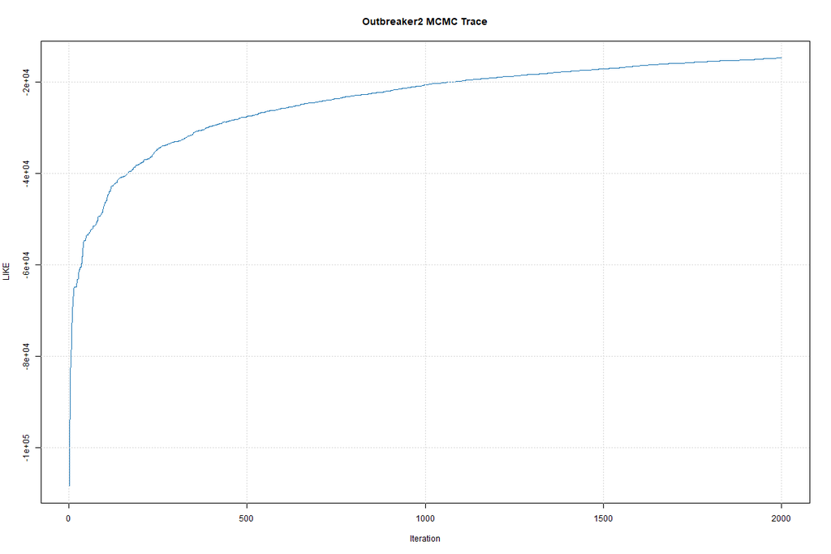

**MCMC Log-Likelihood Trace**

Inspect for convergence: a stable horizontal band indicates good chain mixing. Visible drift, cycles, or sudden jumps suggest poor convergence — treat all model output as exploratory until convergence is confirmed.

⬇ Download

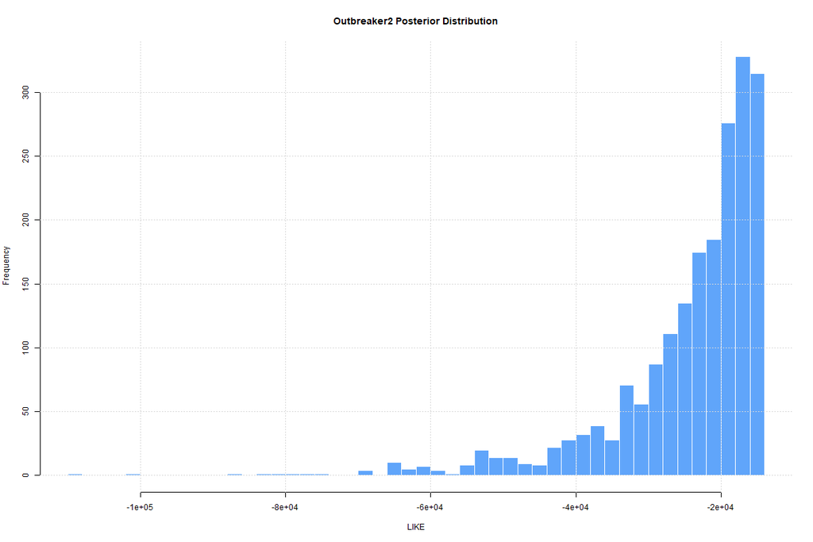

**MCMC Log-Likelihood Distribution**

A near-normal, unimodal histogram indicates the sampler explored the posterior well. Multi-modal or heavily skewed distributions suggest the chain has not converged — model-prioritised transmission links should be interpreted with caution.

⬇ Download

## Transmission network

| Generated at | 2026-05-14T10:20:06Z |
| --- | --- |
| Inference source | outbreaker2_posterior |
| Provenance | real |
| Node count | 25 |
| Edge count | 24 |
| High-confidence edges | 21 |

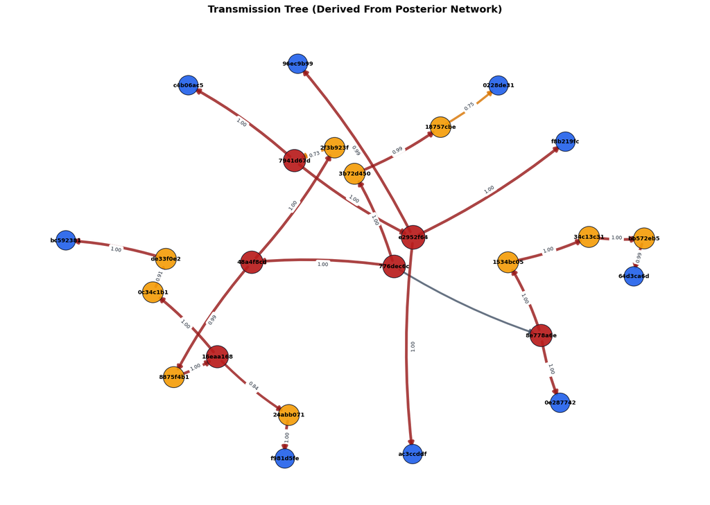

**Posterior Transmission Tree**

Arrows show the most probable who-infected-whom direction from outbreaker2 posterior marginal modes. These are probabilistic hypotheses, not confirmed routes. Validate each link with pairwise SNP distance ≤12 and epidemiological corroboration before operational action.

⬇ Download

### Priority nodes

| Case | Cluster | Region | Risk score | Risk band | Outgoing | Incoming |
| --- | --- | --- | --- | --- | --- | --- |
| e2952f64 |  |  | 2.3879 | high | 3 | 1 |
| 776dec6c |  |  | 1.8191 | high | 3 | 0 |
| 48a4f8cd |  |  | 1.6916 | high | 2 | 1 |
| 7941d67d |  |  | 1.6186 | high | 2 | 1 |
| 16eaa168 |  |  | 1.5885 | high | 2 | 1 |
| 8e778a6e |  |  | 1.5796 | high | 2 | 1 |
| 1534bc05 |  |  | 1 | medium | 1 | 1 |
| 34c13c31 |  |  | 1 | medium | 1 | 1 |
| 8875f4b1 |  |  | 0.9964 | medium | 1 | 1 |
| 3b72d450 |  |  | 0.9963 | medium | 1 | 1 |

### Transmission links

| From | To | Probability | Confidence | Inference |
| --- | --- | --- | --- | --- |
| 776dec6c-f247-4904-a7b4-e512ab395b0c | 48a4f8cd-327c-4f96-a290-184ab378b5c5 | 1 | high | posterior_marginal_mode |
| 48a4f8cd-327c-4f96-a290-184ab378b5c5 | 8875f4b1-34ca-4d12-9adf-50d58c3c8381 | 0.988 | high | posterior_marginal_mode |
| 3b72d450-6960-4963-bd26-374c422ccf5a | 18757cbe-7e60-4363-9353-f7f856b5b33f | 0.9947 | high | posterior_marginal_mode |
| 18757cbe-7e60-4363-9353-f7f856b5b33f | 0228de31-42d0-4c71-b4d1-a155a19f2ce6 | 0.746 | medium | posterior_marginal_mode |
| 8875f4b1-34ca-4d12-9adf-50d58c3c8381 | 16eaa168-463e-4cd1-9303-78d707438e46 | 1 | high | posterior_marginal_mode |
| 48a4f8cd-327c-4f96-a290-184ab378b5c5 | 2f3b923f-b56b-46f3-a1fe-d9c9a381d632 | 1 | high | posterior_marginal_mode |
| 776dec6c-f247-4904-a7b4-e512ab395b0c | 3b72d450-6960-4963-bd26-374c422ccf5a | 1 | high | posterior_marginal_mode |
| 16eaa168-463e-4cd1-9303-78d707438e46 | 24abb071-ee81-42d6-b22b-a81ccffa512d | 0.8407 | high | posterior_marginal_mode |
| 776dec6c-f247-4904-a7b4-e512ab395b0c | 8e778a6e-dcdd-4738-a925-8d93311dc809 | 0.5987 | low | posterior_marginal_mode |
| 8e778a6e-dcdd-4738-a925-8d93311dc809 | 0e287742-c7ea-4393-9dff-7afcedfb9b33 | 1 | high | posterior_marginal_mode |
| 16eaa168-463e-4cd1-9303-78d707438e46 | 0c34c1b1-13ce-4694-a00e-1d22a3c1a88b | 1 | high | posterior_marginal_mode |
| 2f3b923f-b56b-46f3-a1fe-d9c9a381d632 | 7941d67d-0559-4014-a5d6-272ebe72ccb7 | 0.7287 | medium | posterior_marginal_mode |
| 8e778a6e-dcdd-4738-a925-8d93311dc809 | 1534bc05-a73b-481a-a76f-8cb935466f7a | 1 | high | posterior_marginal_mode |
| 1534bc05-a73b-481a-a76f-8cb935466f7a | 34c13c31-4381-4636-9b6d-eed539ce7cfb | 1 | high | posterior_marginal_mode |
| 0c34c1b1-13ce-4694-a00e-1d22a3c1a88b | de33f0e2-ba3a-46c8-a219-c209bc2ed50f | 0.914 | high | posterior_marginal_mode |
| 7941d67d-0559-4014-a5d6-272ebe72ccb7 | c4b06ac5-bbca-4224-99c8-e1537f8a9195 | 1 | high | posterior_marginal_mode |
| 34c13c31-4381-4636-9b6d-eed539ce7cfb | bb572eb5-58ed-4c24-b1b1-ce1aaaf64f81 | 1 | high | posterior_marginal_mode |
| 24abb071-ee81-42d6-b22b-a81ccffa512d | f981d5fe-af17-4824-bc7f-9847062aa66a | 1 | high | posterior_marginal_mode |
| bb572eb5-58ed-4c24-b1b1-ce1aaaf64f81 | 64d3ca6d-a318-419a-9326-2406dd388fac | 0.9927 | high | posterior_marginal_mode |
| de33f0e2-ba3a-46c8-a219-c209bc2ed50f | bc592381-c7fc-44b9-9a86-387ba7156e01 | 1 | high | posterior_marginal_mode |
| 7941d67d-0559-4014-a5d6-272ebe72ccb7 | e2952f64-0ccb-41be-a200-ab749af8d499 | 1 | high | posterior_marginal_mode |
| e2952f64-0ccb-41be-a200-ab749af8d499 | 96ec9b99-df6c-4c5a-a261-913ab0d1484b | 0.986 | high | posterior_marginal_mode |
| e2952f64-0ccb-41be-a200-ab749af8d499 | f8b219fc-5c52-411a-88bd-b399534f5283 | 1 | high | posterior_marginal_mode |
| e2952f64-0ccb-41be-a200-ab749af8d499 | ac3ccddf-6d9d-4c82-b09f-338cd95624b3 | 0.9967 | high | posterior_marginal_mode |

## Model-prioritised transmission hypotheses

**Do not escalate model-only or genomically discordant links to field investigation** without genomic and epidemiological corroboration. Posterior probability ≥0.70 indicates a plausible transmission event, but genomic validation is essential.

0 SNP-linked 0 Model-only 7 D1: SNP>12 16 QC-unresolved

The **Epidemiological link** and **Final classification** columns below are pre-populated with default values. The MDT should review each pair and record the final adjudication decision in the case management system before external circulation.

#### Genomically discordant (posterior ≥0.70, SNP >12)

| Pair | Posterior | SNP dist | QC src/rec | Genomic flag | Epidemiological link | Final classification |
| --- | --- | --- | --- | --- | --- | --- |
| 8e778a6e→1534bc05 | 1.000 | 21 | pass/pass | D1: SNP>12 | *Awaiting epi review* | Do not escalate — SNP discordant |
| 1534bc05→34c13c31 | 1.000 | 16 | pass/pass | D1: SNP>12 | *Awaiting epi review* | Do not escalate — SNP discordant |
| 7941d67d→c4b06ac5 | 1.000 | 881 | pass/pass | D1: SNP>12 | *Awaiting epi review* | Do not escalate — SNP discordant |
| 34c13c31→bb572eb5 | 1.000 | 13 | pass/pass | D1: SNP>12 | *Awaiting epi review* | Do not escalate — SNP discordant |
| 7941d67d→e2952f64 | 1.000 | 17 | pass/pass | D1: SNP>12 | *Awaiting epi review* | Do not escalate — SNP discordant |
| e2952f64→f8b219fc | 1.000 | 18 | pass/pass | D1: SNP>12 | *Awaiting epi review* | Do not escalate — SNP discordant |
| e2952f64→ac3ccddf | 0.997 | 16 | pass/pass | D1: SNP>12 | *Awaiting epi review* | Do not escalate — SNP discordant |

#### QC-unresolved — hold pending repeat sequencing

| Pair | Posterior | SNP dist | QC src/rec | Genomic flag | Epidemiological link | Final classification |
| --- | --- | --- | --- | --- | --- | --- |
| 776dec6c→48a4f8cd | 1.000 | n/a | not_reported/pass | QC-unresolved | *Awaiting epi review* | Hold — repeat sequencing required |
| 8875f4b1→16eaa168 | 1.000 | n/a | not_reported/not_reported | QC-unresolved | *Awaiting epi review* | Hold — repeat sequencing required |
| 48a4f8cd→2f3b923f | 1.000 | 16 | pass/fail | QC-unresolved | *Awaiting epi review* | Hold — repeat sequencing required |
| 776dec6c→3b72d450 | 1.000 | n/a | not_reported/pass | QC-unresolved | *Awaiting epi review* | Hold — repeat sequencing required |
| 8e778a6e→0e287742 | 1.000 | 28 | pass/fail | QC-unresolved | *Awaiting epi review* | Hold — repeat sequencing required |
| 16eaa168→0c34c1b1 | 1.000 | n/a | not_reported/not_reported | QC-unresolved | *Awaiting epi review* | Hold — repeat sequencing required |
| 24abb071→f981d5fe | 1.000 | 22 | pass/fail | QC-unresolved | *Awaiting epi review* | Hold — repeat sequencing required |
| de33f0e2→bc592381 | 1.000 | 864 | fail/fail | QC-unresolved | *Awaiting epi review* | Hold — repeat sequencing required |
| 3b72d450→18757cbe | 0.995 | 890 | pass/fail | QC-unresolved | *Awaiting epi review* | Hold — repeat sequencing required |
| bb572eb5→64d3ca6d | 0.993 | 15 | pass/fail | QC-unresolved | *Awaiting epi review* | Hold — repeat sequencing required |
| 48a4f8cd→8875f4b1 | 0.988 | n/a | pass/not_reported | QC-unresolved | *Awaiting epi review* | Hold — repeat sequencing required |
| e2952f64→96ec9b99 | 0.986 | 883 | pass/fail | QC-unresolved | *Awaiting epi review* | Hold — repeat sequencing required |
| 0c34c1b1→de33f0e2 | 0.914 | n/a | not_reported/fail | QC-unresolved | *Awaiting epi review* | Hold — repeat sequencing required |
| 16eaa168→24abb071 | 0.841 | n/a | not_reported/pass | QC-unresolved | *Awaiting epi review* | Hold — repeat sequencing required |
| 18757cbe→0228de31 | 0.746 | n/a | fail/not_reported | QC-unresolved | *Awaiting epi review* | Hold — repeat sequencing required |
| 2f3b923f→7941d67d | 0.729 | 19 | fail/pass | QC-unresolved | *Awaiting epi review* | Hold — repeat sequencing required |

## Pairwise SNP distance summary

≤12 SNPs = operational threshold for probable recent transmission. >12 SNPs = direct transmission unlikely. SNP unavailable = repeat sequencing required before inference.

| SNP distance category | Pairs | Operational implication |
| --- | --- | --- |
| 0–5 SNPs (direct) | 0 | Immediate: probable direct transmission — contact trace; confirm epi link |
| 6–12 SNPs (probable) | 0 | Priority: probable cluster; review shared setting and exposures |
| 13–25 SNPs (possible shared source) | 30 | Review: possible shared source/reactivation; epi adjudication required |
| >25 SNPs (unlikely direct) | 160 | Low priority: unlikely direct recent transmission; monitor only |
| SNP unavailable | 5 | Hold: repeat sequencing or QC resolution required before inference |

## Current outbreak interpretation

**At present, there are no SNP-supported direct transmission links** (no pairs meeting both posterior ≥0.70 and SNP distance ≤12 criteria). The outbreaker2 output identifies model-prioritised transmission hypotheses only.

There are **0** model-only link(s) (no pairwise SNP confirmation), **16** QC-unresolved pair(s) pending repeat sequencing, and **7** genomically discordant pair(s) (model-linked but SNP >12).

**Operational action should focus on:** (1) resolving QC failures and contamination flags, (2) validating drug-resistance gene-drug mapping and confirming phenotypic DST, (3) completing epidemiological linkage data for 3 open cluster(s), (4) populating all 0 missing reproducibility field(s) before external circulation.

This statement is automatically generated from available data. It must be reviewed and countersigned by the responsible public health physician before inclusion in any formal outbreak report.

### Counts and denominators in this report

Definitions match the denominator box above. All model-prioritised links are hypotheses only — zero SNP-supported links means no validated direct transmission candidates at this time.

[output not shown]

### Discordant pairs

| Pair | SNP dist | Posterior | Code | Interpretation |
| --- | --- | --- | --- | --- |
| 2f3b923f-48a4f8cd | 16 | 1.000 | D1 | Temporal support without pairwise SNP support |
| 34c13c31-bb572eb5 | 13 | 1.000 | D1 | Temporal support without pairwise SNP support |
| 0e287742-8e778a6e | 28 | 1.000 | D1 | Temporal support without pairwise SNP support |
| 1534bc05-34c13c31 | 16 | 1.000 | D1 | Temporal support without pairwise SNP support |
| 1534bc05-8e778a6e | 21 | 1.000 | D1 | Temporal support without pairwise SNP support |
| e2952f64-f8b219fc | 18 | 1.000 | D1 | Temporal support without pairwise SNP support |
| 24abb071-f981d5fe | 22 | 1.000 | D1 | Temporal support without pairwise SNP support |
| 7941d67d-c4b06ac5 | 881 | 1.000 | D1 | Temporal support without pairwise SNP support |
| 3b72d450-776dec6c | n/a | 1.000 | D2 | Temporal support without pairwise SNP support |
| 0c34c1b1-16eaa168 | n/a | 1.000 | D2 | Temporal support without pairwise SNP support |
| 48a4f8cd-776dec6c | n/a | 1.000 | D2 | Temporal support without pairwise SNP support |
| bc592381-de33f0e2 | 864 | 1.000 | D1 | Temporal support without pairwise SNP support |
| 16eaa168-8875f4b1 | n/a | 1.000 | D2 | Temporal support without pairwise SNP support |
| 7941d67d-e2952f64 | 17 | 1.000 | D1 | Temporal support without pairwise SNP support |
| ac3ccddf-e2952f64 | 16 | 0.997 | D1 | Temporal support without pairwise SNP support |
| 18757cbe-3b72d450 | 890 | 0.995 | D1 | Temporal support without pairwise SNP support |
| 64d3ca6d-bb572eb5 | 15 | 0.993 | D1 | Temporal support without pairwise SNP support |
| 48a4f8cd-8875f4b1 | n/a | 0.988 | D2 | Temporal support without pairwise SNP support |
| 96ec9b99-e2952f64 | 883 | 0.986 | D1 | Temporal support without pairwise SNP support |
| 0c34c1b1-de33f0e2 | n/a | 0.914 | D2 | Temporal support without pairwise SNP support |
| 16eaa168-24abb071 | n/a | 0.841 | D2 | Temporal support without pairwise SNP support |
| 0228de31-18757cbe | n/a | 0.746 | D2 | Temporal support without pairwise SNP support |
| 2f3b923f-7941d67d | 19 | 0.729 | D1 | Temporal support without pairwise SNP support |
| 776dec6c-8e778a6e | n/a | 0.599 | D2 | Temporal support without pairwise SNP support |

D1: outbreaker-linked, SNP>12. D2: outbreaker-linked, SNP unavailable. D3: SNP-linked, no outbreaker direction.

## Programme surveillance KPIs (last 12 weeks)

[output not shown]

### Regional sequencing representativeness

| Region | Eligible | Sequenced | Coverage |
| --- | --- | --- | --- |
| United Kingdom | 5 | 5 | 100.0% |

## Weekly surveillance trends (12 weeks)

| Week | Eligible | Sequenced | Coverage % | QC pass % |
| --- | --- | --- | --- | --- |
| 2026-02-23 | 1 | 1 | 100.0% | 100.0% |
| 2026-03-02 | 1 | 1 | 100.0% | 0.0% |
| 2026-03-09 | 1 | 1 | 100.0% | 100.0% |
| 2026-03-16 | 0 | 0 | n/a | n/a |
| 2026-03-23 | 0 | 0 | n/a | n/a |
| 2026-03-30 | 0 | 0 | n/a | n/a |
| 2026-04-06 | 0 | 0 | n/a | n/a |
| 2026-04-13 | 0 | 0 | n/a | n/a |
| 2026-04-20 | 0 | 0 | n/a | n/a |
| 2026-04-27 | 0 | 0 | n/a | n/a |
| 2026-05-04 | 1 | 1 | 100.0% | 100.0% |
| 2026-05-11 | 0 | 0 | n/a | n/a |

## QC failure drill-down

QC pass

12

60.0% pass rate

QC fail

8

Low coverage / threshold breach

Contamination

1

Mixed signal — exclude pending repeat

Not reported

5

QC metadata absent — treat as unresolved

Excluded from inference

13

QC fail or contamination

### QC pass/fail thresholds applied

[output not shown]

Samples with QC status *not reported* are treated as unresolved and excluded from cluster inference pending review. Thresholds above are defaults — site-specific SOP values override these if recorded in the pipeline provenance.

### Sample-level QC detail

Samples highlighted red require repeat sequencing or resolution before operational inference. Contaminated samples must be excluded from cluster assignment pending repeat. The **qc_failure_reason** field (from sample_qc_metrics) is shown where available.

| Sample | QC status | Coverage % | Mean depth | Contamination | Action |
| --- | --- | --- | --- | --- | --- |
| 96ec9b99 | fail | 92.8 | 64.8 | no | Repeat |
| bc592381 | fail | 92.9 | 264.4 | yes | Repeat |
| 64d3ca6d | fail | 93.9 | 173.4 | no | Repeat |
| f981d5fe | fail | 94.2 | 197.5 | no | Repeat |
| de33f0e2 | fail | 93.6 | 151.6 | no | Repeat |
| 0c34c1b1 | not_reported | n/a | n/a | no | Repeat |
| 0e287742 | fail | 94.6 | 89.5 | no | Repeat |
| 2f3b923f | fail | 92.2 | 275.3 | no | Repeat |
| 0228de31 | not_reported | n/a | n/a | no | Repeat |
| 16eaa168 | not_reported | n/a | n/a | no | Repeat |
| 18757cbe | fail | 92.7 | 73.4 | no | Repeat |
| 8875f4b1 | not_reported | n/a | n/a | no | Repeat |
| 776dec6c | not_reported | n/a | n/a | no | Repeat |

## Run-level QC summary

Runs with fail rate >20% or mean coverage <95% should be reviewed before results are used for cluster assignment.

| Run date (proxy) | Samples | Pass | Fail | Fail % | Mean depth | Mean coverage % |
| --- | --- | --- | --- | --- | --- | --- |
| 2026-05-13 | 2 | 1 | 1 | 50.0% | 177.5 | 95.6 |
| 2026-05-11 | 1 | 0 | 1 | 100.0% | 173.4 | 93.9 |
| 2026-04-05 | 1 | 1 | 0 | 0.0% | 100.6 | 98.7 |
| 2026-03-26 | 1 | 0 | 1 | 100.0% | 64.8 | 92.8 |
| 2026-03-23 | 1 | 0 | 1 | 100.0% | 73.4 | 92.7 |
| 2026-03-19 | 1 | 1 | 0 | 0.0% | 254.6 | 97.8 |
| 2026-03-03 | 1 | 1 | 0 | 0.0% | 103.1 | 98.4 |
| 2026-02-20 | 1 | 0 | 1 | 100.0% | 89.5 | 94.6 |
| 2026-02-12 | 1 | 0 | 1 | 100.0% | 197.5 | 94.2 |
| 2026-02-01 | 1 | 1 | 0 | 0.0% | 101.4 | 97.1 |
| 2026-01-30 | 1 | 1 | 0 | 0.0% | 80.7 | 95.2 |
| 2026-01-25 | 1 | 1 | 0 | 0.0% | 194.1 | 95.0 |
| 2025-12-05 | 1 | 0 | 1 | 100.0% | 151.6 | 93.6 |
| 2025-11-23 | 1 | 1 | 0 | 0.0% | 210.1 | 96.7 |
| 2025-11-06 | 1 | 1 | 0 | 0.0% | 195.4 | 99.0 |
| 2025-10-13 | 1 | 1 | 0 | 0.0% | 246.1 | 97.6 |
| 2025-09-04 | 1 | 1 | 0 | 0.0% | 240.0 | 98.0 |
| 2025-06-02 | 1 | 1 | 0 | 0.0% | 209.5 | 99.8 |
| 2025-03-29 | 1 | 0 | 1 | 100.0% | 275.3 | 92.2 |

Rows highlighted red have fail rate >20%. Assign run_id to enable full run-level audit.

## Lineage and drug-resistance summary

[output not shown]

**Top lineages:** L4: 12, L2: 7, L3: 4, L1: 2

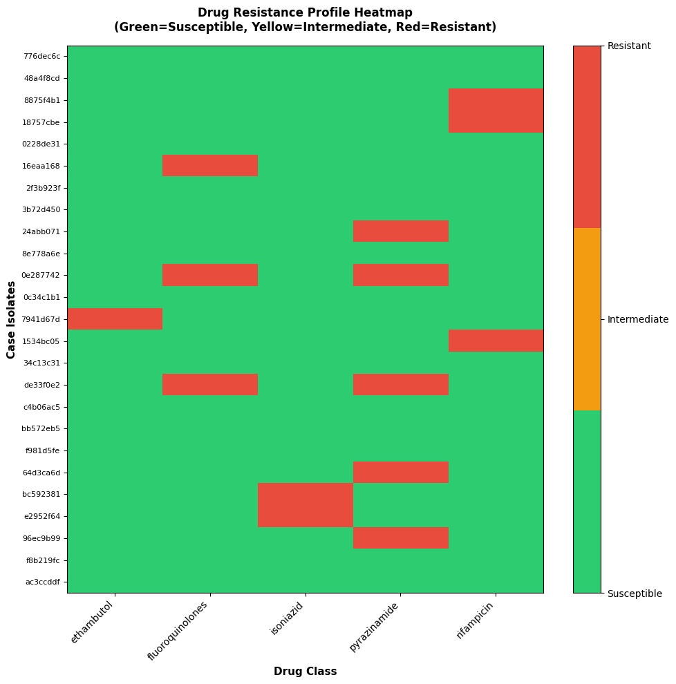

**Drug Resistance Profile Heatmap**

Rows = case isolates, columns = drug classes. Green = susceptible, yellow = intermediate, red = resistant. All genomic resistance predictions must be confirmed by phenotypic DST before clinical use.

⬇ Download

## Drug-resistance mutation details

**🚫 BLOCKING SAFETY ISSUE — Drug-resistance pipeline validation required before any clinical or operational use.**  
Unusual gene-drug mappings have been detected (e.g. *gyrA* linked to pyrazinamide, *embB* linked to fluoroquinolones, *pncA* linked to rifampicin). These indicate a likely bioinformatics pipeline data-mapping error.

- All resistance calls with Unusual gene-drug mapping are classified as **Suppressed** — must not be reported, acted on, or shared until the pipeline is validated.
- Resistance calls with Valid expected gene are classified as **Not validated** — require phenotypic DST confirmation before clinical use.
- No resistance call in this report should be treated as **Validated** until a formal pipeline audit is complete and phenotypic DST results are available.

Quarantine all affected samples. Notify the bioinformatics lead immediately. Do not include resistance findings from this report in patient records or MDT summaries until resolved.  
Catalogue: **WHO TB catalogue v2 (2023)** · Pipeline validation status: Not validated — under review

**Gene-drug reference mapping**

| Drug | Expected genes |
| --- | --- |
| Rifampicin | rpoB |
| Isoniazid | katG, inhA, fabG1 |
| Pyrazinamide | pncA |
| Ethambutol | embB |
| Fluoroquinolones | gyrA, gyrB |
| Aminoglycosides / injectables | rrs, eis, tlyA |

| Case | Drug | Mutation | Gene | Gene-drug status | Confidence | Predicted profile |
| --- | --- | --- | --- | --- | --- | --- |
| 0e287742 | pyrazinamide | C15T | gyrA | Unusual gene-drug mapping | n/a | pyrazinamide, fluoroquinolones |
| 0e287742 | fluoroquinolones | S531L | embB | Unusual gene-drug mapping | n/a | pyrazinamide, fluoroquinolones |
| 1534bc05 | rifampicin | C15T | pncA | Unusual gene-drug mapping | n/a | rifampicin |
| 16eaa168 | fluoroquinolones | H526Y | gyrA | Valid expected gene | n/a | fluoroquinolones |
| 18757cbe | rifampicin | H526Y | gyrA | Unusual gene-drug mapping | n/a | rifampicin |
| 24abb071 | pyrazinamide | Q431K | rpoB | Unusual gene-drug mapping | n/a | pyrazinamide |
| 64d3ca6d | pyrazinamide | S531L | gyrA | Unusual gene-drug mapping | n/a | pyrazinamide |
| 7941d67d | ethambutol | S315T | pncA | Unusual gene-drug mapping | n/a | ethambutol |
| 8875f4b1 | rifampicin | Q431K | rpoB | Valid expected gene | n/a | rifampicin |
| 96ec9b99 | pyrazinamide | D516V | gyrA | Unusual gene-drug mapping | n/a | pyrazinamide |
| bc592381 | isoniazid | S531L | gyrA | Unusual gene-drug mapping | n/a | isoniazid |
| de33f0e2 | pyrazinamide | Q431K | katG | Unusual gene-drug mapping | n/a | pyrazinamide, fluoroquinolones |
| de33f0e2 | fluoroquinolones | C15T | inhA | Unusual gene-drug mapping | n/a | pyrazinamide, fluoroquinolones |
| e2952f64 | isoniazid | H526Y | inhA | Valid expected gene | n/a | isoniazid |

## Cluster epidemiology

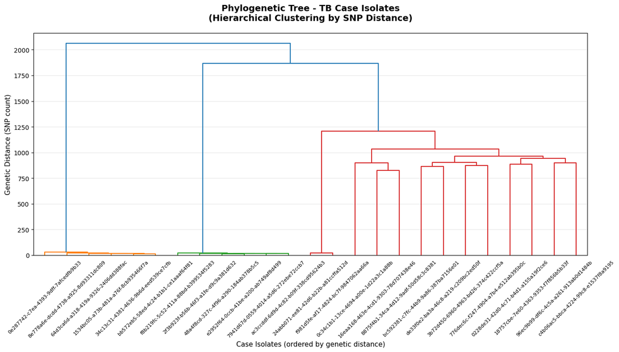

**Hierarchical Clustering Dendrogram (SNP Distance)**

Cases joined at a low branch height share recent common ancestry. Visible compact sub-trees correspond to transmission clusters. Branch heights are proportional to pairwise SNP distance — cases below the 12-SNP threshold are likely directly linked.

⬇ Download

[output not shown]

### Cluster growth status

| Cluster | Cases | Last case | Cases 30d | Cases 60d | Cases 90d | Growth status |
| --- | --- | --- | --- | --- | --- | --- |
| c8758811 | 6 | 2026-05-05 | 1 | 1 | 3 | Active |
| 4dfeb4b4 | 6 | 2026-01-28 | 0 | 0 | 0 | Slowing |
| de2c22d4 | 2 | 2026-01-08 | 0 | 0 | 0 | Slowing |

Active = last case <90 days; Slowing = 90–180 days; Likely inactive = >180 days. Formal closure requires MDT sign-off.

## Cluster prioritisation

Priority score = case count×2 + cross-region spread×3 + recency (14/30/60d = 3/2/1) + open status×3. Scores >10 warrant prioritised MDT review.

| Cluster | Cases | Regions | Most recent | Status | Priority score |
| --- | --- | --- | --- | --- | --- |
| c8758811-1b9 | 6 | 1 | 2026-05-05 | open | **21** |
| 4dfeb4b4-a26 | 6 | 1 | 2026-01-28 | open | **18** |
| de2c22d4-58d | 2 | 1 | 2026-01-08 | open | **10** |

## Method comparison & secondary engines

### Cross-method clustering comparison

| Sequence assigned cases | 14 |
| --- | --- |
| Outbreaker assigned cases | 25 |
| Overlap cases | 14 |
| Pairwise precision | 0.341 |
| Pairwise recall | 1.0 |
| Pairwise Jaccard | 0.341 |

### Sequence clustering snapshot

| Cluster Count | 3 |
| --- | --- |

## Data provenance and reproducibility

Fields marked Missing — required are mandatory for external circulation. Fields marked Not recorded are optional but strongly recommended for audit and reproducibility.

| Reference genome | H37Rv (NC_000962.3) |
| --- | --- |
| SNP-calling pipeline/version | TB-WGS-Outbreak-Pipeline |
| Resistance catalogue/version | WHO TB catalogue v2 (2023) |
| Lineage-calling tool/version | TBProfiler v5.0.0 |
| outbreaker2 version | outbreaker2 1.4.4 |
| Random seed | 42 |
| Sequencing platform | Illumina |
| Instrument | NextSeq 550 (synthetic) |
| Library prep method | Nextera XT |
| Mapping tool | BWA-MEM 0.7.17 |
| Variant caller | GATK HaplotypeCaller 4.4.0 |
| SNP cluster threshold | 12 |
| Generation time mean (d) | 7 |
| Generation time SD (d) | 2 |
| Sampling probability (π) | 0.85 |
| Pipeline run date | Not recorded |
| Analysis provenance date | Not recorded |

All mandatory reproducibility fields are present. Confirm catalogue and tool versions with the bioinformatics lead before circulation.

## Epidemiological data completeness

Completeness of fields capturable from the genomic pipeline. Additional clinical and field epi data must be completed in the case management system.

| Field | Populated | Missing | Completeness |
| --- | --- | --- | --- |
| Specimen date | 25 | 0 | 100.0% |
| Geographic region | 25 | 0 | 100.0% |
| Lineage called | 25 | 0 | 100.0% |
| Drug resistance called | 25 | 0 | 100.0% |
| QC status recorded | 20 | 5 | 80.0% |
| Cluster assigned | 14 | 11 | 56.0% |

**Missing epi data domains** (not directly capturable from genomic pipeline — require field data completion):  
Demographics (age band, sex, country of birth, time in UK), Clinical infectiousness (pulmonary/extrapulmonary, smear status, cavitation, cough duration), Exposure setting (household, workplace, hostel, prison, healthcare, congregate setting), Contact tracing (named contacts, shared venues, tracing status), Vulnerability factors (homelessness, substance use, immunosuppression, migrant health, prison history), Timeline (symptom onset, diagnosis, isolation, treatment start, sequencing date). Complete these fields in the case management system for MDT review.

### Mandatory epi-completeness — by cluster

RAG status: Red — incomplete = minimum fields not confirmed in case management system. No cluster may be signed off at MDT until all Red fields are resolved.

| Cluster | Cases | Demographics | Exposure setting | Contact tracing | Vulnerability factors | Timeline complete | MDT sign-off status |
| --- | --- | --- | --- | --- | --- | --- | --- |
| c8758811-1b9 | 6 | Red — incomplete | Red — incomplete | Red — incomplete | Red — incomplete | Red — incomplete | Blocked — epi incomplete |
| 4dfeb4b4-a26 | 6 | Red — incomplete | Red — incomplete | Red — incomplete | Red — incomplete | Red — incomplete | Blocked — epi incomplete |
| de2c22d4-58d | 2 | Red — incomplete | Red — incomplete | Red — incomplete | Red — incomplete | Red — incomplete | Blocked — epi incomplete |

**No cluster may be signed off at MDT until all Red fields are resolved.** Complete field epi data in the case management system before MDT review.

### Minimum epi fields required before MDT sign-off

| Epi domain | Minimum fields required | Source | Status |
| --- | --- | --- | --- |
| Demographics | Age band, sex, country of birth, time in UK (≥1 year / <1 year) | Case management system | Not confirmed — complete before MDT |
| Clinical infectiousness | Pulmonary / extrapulmonary, smear status, cavitation on CXR | Microbiology / Radiology | Not confirmed — complete before MDT |
| Exposure setting | At least one confirmed shared setting (household, workplace, congregation) | TB nurses / HPT | Not confirmed — complete before MDT |
| Contact tracing | Named contacts listed; tracing initiated or documented as not applicable | Contact tracing team | Not confirmed — complete before MDT |
| Vulnerability factors | Homelessness, substance use, immunosuppression screened (yes / no / unknown) | TB nurses / Social care | Not confirmed — complete before MDT |
| Case timeline | Symptom onset (est.), diagnosis date, treatment start, sequencing date | Clinical / Lab records | Not confirmed — complete before MDT |

## Appendix A — Case-level operational actions

**REPORT INCOMPLETE — Appendix A is missing.** No case-level action export was found. This appendix is required for MDT sign-off. The report cannot be circulated until Appendix A is populated. Generate the PDF report first to populate `exports/appendix_a_case_level_actions.csv`, then re-generate this HTML report.

## Appendix B — Full discordance review

**REPORT INCOMPLETE — Appendix B is missing.** No discordance review export was found. This appendix is required for MDT governance. The report cannot be circulated until Appendix B is populated. Run the discordance review export and re-generate this HTML report.

## Figures overview

All generated figures. Click any image to zoom; use the download link to save. Figures are also embedded inline within their relevant report sections above.

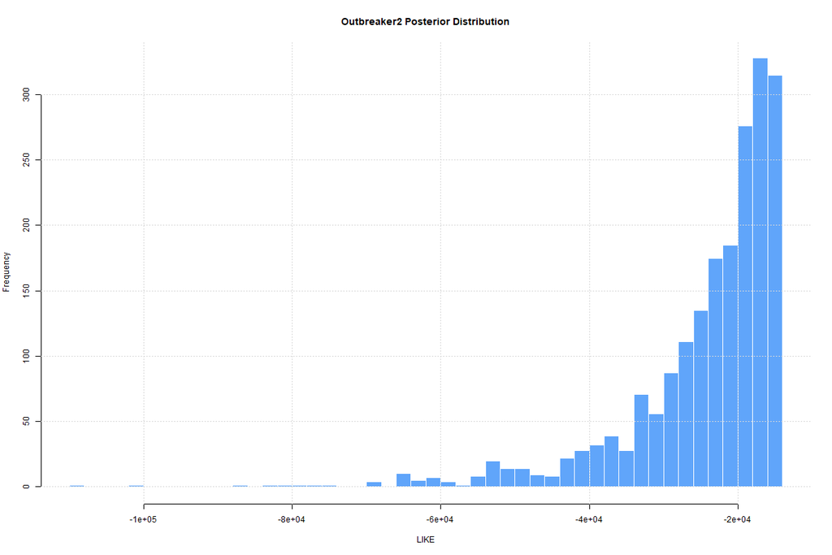

**MCMC Log-Likelihood Distribution**

A near-normal, unimodal histogram indicates the sampler explored the posterior well. Multi-modal or heavily skewed distributions suggest the chain has not converged — model-prioritised transmission links should be interpreted with caution.

⬇ Download

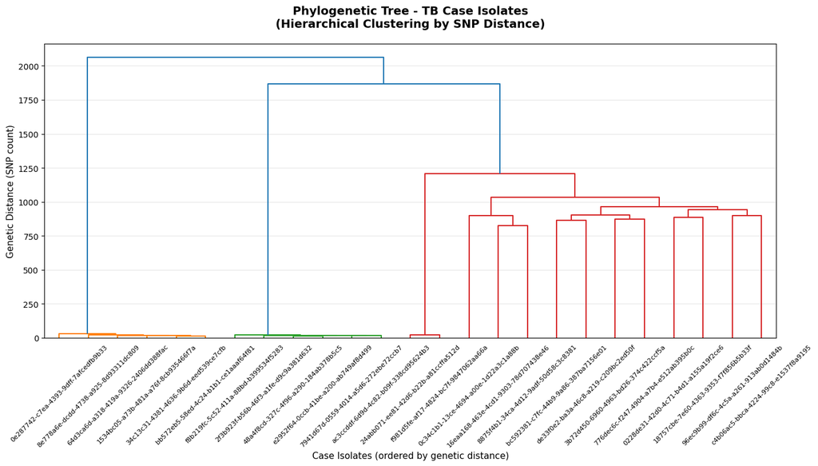

**Hierarchical Clustering Dendrogram (SNP Distance)**

Cases joined at a low branch height share recent common ancestry. Visible compact sub-trees correspond to transmission clusters. Branch heights are proportional to pairwise SNP distance — cases below the 12-SNP threshold are likely directly linked.

⬇ Download

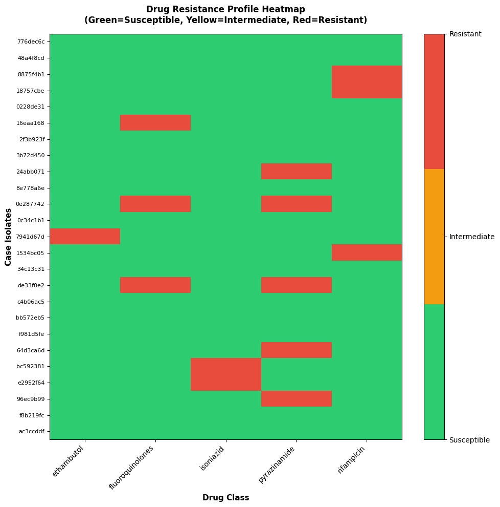

**Drug Resistance Profile Heatmap**

Rows = case isolates, columns = drug classes. Green = susceptible, yellow = intermediate, red = resistant. All genomic resistance predictions must be confirmed by phenotypic DST before clinical use.

⬇ Download

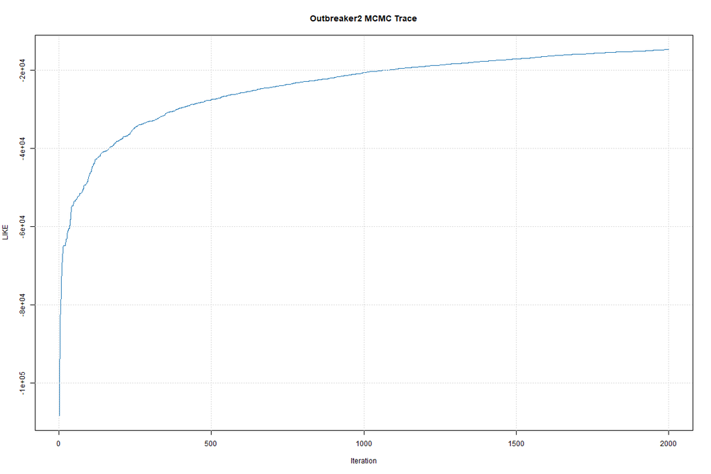

**MCMC Log-Likelihood Trace**

Inspect for convergence: a stable horizontal band indicates good chain mixing. Visible drift, cycles, or sudden jumps suggest poor convergence — treat all model output as exploratory until convergence is confirmed.

⬇ Download

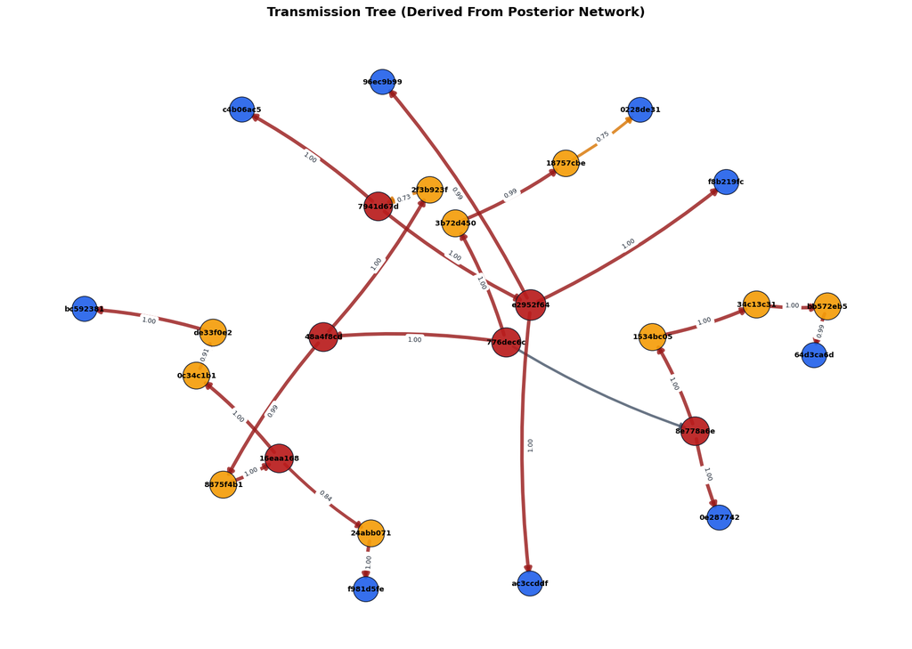

**Posterior Transmission Tree**

Arrows show the most probable who-infected-whom direction from outbreaker2 posterior marginal modes. These are probabilistic hypotheses, not confirmed routes. Validate each link with pairwise SNP distance ≤12 and epidemiological corroboration before operational action.

⬇ Download

## Key concepts (Appendix D)

Click to expand each definition.

**Whole-Genome Sequencing (WGS)**

Reads the complete ~4.4 Mb genome of M. tuberculosis. More informative than conventional typing (MIRU, spoligotyping).

**SNP**

A single base-pair difference. Closely related strains share few SNPs. Used as a genetic distance metric.

**SNP threshold for transmission**

≤12 SNPs: potentially linked (UK NICE). ≤5 SNPs: recent direct transmission likely. >50 SNPs: recent shared transmission effectively ruled out.

**Lineage**

M. tuberculosis classified into 7+ major lineages (L1–L7). Influences drug-resistance patterns and transmissibility.

**Cluster**

Cases genetically similar within the SNP threshold. Does not prove direct transmission — epidemiological linkage required to confirm routes.

**outbreaker2**

Bayesian MCMC method combining SNP distances with collection dates to probabilistically infer who-infected-whom. Posterior probabilities are hypotheses, not proofs.

**MCMC convergence**

Convergence diagnostic near 1.0 = reliable. Values >1.1 = interpret cautiously.

**Drug resistance**

Genomic mutations predict resistance. MDR-TB = resistant to isoniazid + rifampicin. XDR-TB = additional resistance. Genomic DR requires phenotypic DST confirmation.

## Full machine-readable artifacts

Complete JSON exports used to produce this report.

**Outbreaker2 summary artifact**

[output not shown]

**Transmission network artifact**

[output not shown]

[output not shown]

**Sequence clustering summary**

[output not shown]

**Lineage/DR validation**

[output not shown]

Generated from TB Genomics backend artifacts — 2026-05-14 10:51:20 UTC. For operational use, interpret genomic findings with clinical history, contact tracing, epidemiology, QC status, and local governance review. This is a decision-support tool only.